# Decorrelation-Based Feature Discovery: ARCENE-Whole

Jose Tamez

2023-09-08

# 1 Effect of UPSTM-Based Decorrelation on Feature Discovery

### 1.0.1 Loading the libraries

```r
library("FRESA.CAD")
library(readxl)
library(igraph)
library(umap)
library(tsne)
library(entropy)

op <- par(no.readonly = TRUE)
pander::panderOptions('digits', 3)
pander::panderOptions('table.split.table', 400)
pander::panderOptions('keep.trailing.zeros',TRUE)
```

## 1.1 Material and Methods

## 1.2 The Data

```r
trainLabeled <- read.delim("~/GitHub/FCA/Data/trainSet.txt")
validLabeled <- read.delim("~/GitHub/FCA/Data/arcene_valid.txt")
wholeArceneSet <- rbind(trainLabeled,validLabeled)


wholeArceneSet$Labels <-  1*(wholeArceneSet$Labels > 0)
wholeArceneSet[,1:ncol(trainLabeled)] <- sapply(wholeArceneSet,as.double)
```

#### 1.2.0.1 Standarize the names for the reporting

```r
studyName <- "ARCENE"
dataframe <- wholeArceneSet
outcome <- "Labels"
thro <- 0.8
cexheat = 0.10

TopVariables <- 10
```

## 1.3 Generaring the report

### 1.3.1 Libraries

Some libraries

```r
library(psych)
library(whitening)
library("vioplot")
```

### 1.3.2 Data specs

```r
pander::pander(c(rows=nrow(dataframe),col=ncol(dataframe)-1))
```

| rows | col |
| --- | --- |
| 200 | 10000 |

```r
pander::pander(table(dataframe[,outcome]))
```

| 0 | 1 |
| --- | --- |
| 112 | 88 |

```r
varlist <- colnames(dataframe)
varlist <- varlist[varlist != outcome]

largeSet <- length(varlist) > 1500
```

### 1.3.3 Scaling the data

Scaling and removing near zero variance columns and highly co-linear(r>0.99999) columns

```r
  ### Some global cleaning
  sdiszero <- apply(dataframe,2,sd) > 1.0e-16
  dataframe <- dataframe[,sdiszero]

  varlist <- colnames(dataframe)[colnames(dataframe) != outcome]
  tokeep <- c(as.character(correlated_Remove(dataframe,varlist,thr=0.99999)),outcome)
  dataframe <- dataframe[,tokeep]

  varlist <- colnames(dataframe)
  varlist <- varlist[varlist != outcome]


dataframe <- FRESAScale(dataframe,method="OrderLogit")$scaledData
```

## 1.4 The heatmap of the data

```r
if (!largeSet)
{

  hm <- heatMaps(data=dataframe,
                 Outcome=outcome,
                 Scale=TRUE,
                 hCluster = "row",
                 xlab="Feature",
                 ylab="Sample",
                 srtCol=45,
                 srtRow=45,
                 cexCol=cexheat,
                 cexRow=cexheat
                 )
  par(op)
}
```

#### 1.4.0.1 Correlation Matrix of the Data

The heat map of the data

```r
if (!largeSet)
{

  par(cex=0.6,cex.main=0.85,cex.axis=0.7)
  #cormat <- Rfast::cora(as.matrix(dataframe[,varlist]),large=TRUE)
  cormat <- cor(dataframe[,varlist],method="pearson")
  cormat[is.na(cormat)] <- 0
  gplots::heatmap.2(abs(cormat),
                    trace = "none",
  #                  scale = "row",
                    mar = c(5,5),
                    col=rev(heat.colors(5)),
                    main = "Original Correlation",
                    cexRow = cexheat,
                    cexCol = cexheat,
                     srtCol=45,
                     srtRow=45,
                    key.title=NA,
                    key.xlab="Pearson Correlation",
                    xlab="Feature", ylab="Feature")
  diag(cormat) <- 0
  print(max(abs(cormat)))
}
```

## 1.5 The decorrelation

```r
DEdataframe <- IDeA(dataframe,verbose=TRUE,thr=thro)
```

```
#>
#>  Included: 7108 , Uni p: 0.01644616 , Uncorrelated Base: 343 , Outcome-Driven Size: 0 , Base Size: 343
#>
#>
```

```r
 1 <R=1.000,r=0.975,N= 6558>, Top: 418( 46 )....=[ 2 : 418 Fa= 414 : 0.991 ]( 414 , 2344 , 0 ),<|>Tot Used: 2758 , Added: 2344 , Zero Std: 0 , Max Cor: 1.000
 2 <R=1.000,r=0.975,N= 6558>, Top: 879( 19 )........=[ 2 : 879 Fa= 1279 : 0.992 ]( 865 , 1954 , 414 ),<|>Tot Used: 4602 , Added: 1954 , Zero Std: 0 , Max Cor: 1.000
 3 <R=1.000,r=0.975,N= 6558>, Top: 661( 10 )......[ 1 : 661 Fa= 1927 : 0.975 ]( 656 , 1338 , 1279 ),<|>Tot Used: 5595 , Added: 1338 , Zero Std: 0 , Max Cor: 1.000
 4 <R=1.000,r=0.975,N= 6558>, Top: 356( 17 )...[ 1 : 356 Fa= 2280 : 0.975 ]( 355 , 653 , 1927 ),<|>Tot Used: 6053 , Added: 653 , Zero Std: 0 , Max Cor: 1.000
 5 <R=1.000,r=0.950,N= 3805>, Top: 1237( 10 )...........=( 1 )[ 2 : 1237 Fa= 2709 : 0.963 ]( 1186 , 1626 , 2280 ),<|>Tot Used: 6379 , Added: 1626 , Zero Std: 0 , Max Cor: 1.000
 6 <R=1.000,r=0.950,N= 3805>, Top: 561( 6 ).....[ 1 : 561 Fa= 2888 : 0.950 ]( 552 , 648 , 2709 ),<|>Tot Used: 6479 , Added: 648 , Zero Std: 0 , Max Cor: 1.000
 7 <R=1.000,r=0.950,N= 3805>, Top: 151( 7 ).[ 1 : 151 Fa= 2939 : 0.950 ]( 149 , 215 , 2888 ),<|>Tot Used: 6571 , Added: 215 , Zero Std: 0 , Max Cor: 0.999
 8 <R=0.999,r=0.900,N= 2846>, Top: 1060( 10 )..........=[ 2 : 1060 Fa= 3198 : 0.920 ]( 1018 , 1287 , 2939 ),<|>Tot Used: 6688 , Added: 1287 , Zero Std: 0 , Max Cor: 0.999
 9 <R=0.999,r=0.899,N= 2846>, Top: 298( 1 )..[ 1 : 298 Fa= 3281 : 0.899 ]( 285 , 374 , 3198 ),<|>Tot Used: 6714 , Added: 374 , Zero Std: 0 , Max Cor: 0.999
 10 <R=0.999,r=0.899,N= 2846>, Top: 65( 1 )[ 1 : 65 Fa= 3303 : 0.899 ]( 63 , 128 , 3281 ),<|>Tot Used: 6724 , Added: 128 , Zero Std: 0 , Max Cor: 0.999
 11 <R=0.999,r=0.849,N= 2111>, Top: 781( 4 ).......[ 1 : 781 Fa= 3441 : 0.849 ]( 760 , 940 , 3303 ),<|>Tot Used: 6756 , Added: 940 , Zero Std: 0 , Max Cor: 0.999
 12 <R=0.999,r=0.849,N= 2111>, Top: 216( 1 )..[ 1 : 216 Fa= 3487 : 0.849 ]( 210 , 306 , 3441 ),<|>Tot Used: 6759 , Added: 306 , Zero Std: 0 , Max Cor: 0.999
 13 <R=0.999,r=0.849,N= 2111>, Top: 68( 2 )=[ 2 : 68 Fa= 3495 : 0.877 ]( 62 , 98 , 3487 ),<|>Tot Used: 6763 , Added: 98 , Zero Std: 0 , Max Cor: 0.994
 14 <R=0.994,r=0.800,N= 1605>, Top: 555( 1 ).....[ 1 : 555 Fa= 3566 : 0.800 ]( 546 , 704 , 3495 ),<|>Tot Used: 6775 , Added: 704 , Zero Std: 0 , Max Cor: 0.994
 15 <R=0.994,r=0.800,N= 1605>, Top: 140( 1 ).=[ 2 : 140 Fa= 3587 : 0.840 ]( 137 , 226 , 3566 ),<|>Tot Used: 6780 , Added: 226 , Zero Std: 0 , Max Cor: 0.973
 16 <R=0.973,r=0.800,N= 1605>, Top: 54( 1 )[ 1 : 54 Fa= 3592 : 0.800 ]( 50 , 109 , 3587 ),<|>Tot Used: 6782 , Added: 109 , Zero Std: 0 , Max Cor: 0.973
 17 <R=0.973,r=0.800,N=   52>, Top: 23( 3 )[ 1 : 23 Fa= 3594 : 0.800 ]( 23 , 29 , 3592 ),<|>Tot Used: 6782 , Added: 29 , Zero Std: 0 , Max Cor: 0.952
 18 <R=0.952,r=0.800,N=   52>, Top: 7( 1 )[ 1 : 7 Fa= 3595 : 0.800 ]( 7 , 7 , 3594 ),<|>Tot Used: 6782 , Added: 7 , Zero Std: 0 , Max Cor: 0.837
 19 <R=0.837,r=0.800,N=   52>, Top: 1( 1 )[ 1 : 1 Fa= 3595 : 0.800 ]( 1 , 1 , 3595 ),<|>Tot Used: 6782 , Added: 1 , Zero Std: 0 , Max Cor: 0.800
 20 <R=0.800,r=0.800,N=    0>
 [ 20 ], 0.7999757 Decor Dimension: 6782 Nused: 6782 . Cor to Base: 1416 , ABase: 58 , Outcome Base: 0
varlistc <- colnames(DEdataframe)[colnames(DEdataframe) != outcome]

pander::pander(sum(apply(dataframe[,varlist],2,var)))
```

*10748*

```r
pander::pander(sum(apply(DEdataframe[,varlistc],2,var)))
```

*5772*

```r
pander::pander(entropy(discretize(unlist(dataframe[,varlist]), 256)))
```

*1.82*

```r
pander::pander(entropy(discretize(unlist(DEdataframe[,varlistc]), 256)))
```

*0.992*

### 1.5.1 The decorrelation matrix

```r
if (!largeSet)
{

  par(cex=0.6,cex.main=0.85,cex.axis=0.7)

  UPSTM <- attr(DEdataframe,"UPSTM")

  gplots::heatmap.2(1.0*(abs(UPSTM)>0),
                    trace = "none",
                    mar = c(5,5),
                    col=rev(heat.colors(5)),
                    main = "Decorrelation matrix",
                    cexRow = cexheat,
                    cexCol = cexheat,
                   srtCol=45,
                   srtRow=45,
                    key.title=NA,
                    key.xlab="|Beta|>0",
                    xlab="Output Feature", ylab="Input Feature")

  par(op)
}
```

## 1.6 The heatmap of the decorrelated data

```r
if (!largeSet)
{

  hm <- heatMaps(data=DEdataframe,
                 Outcome=outcome,
                 Scale=TRUE,
                 hCluster = "row",
                 cexRow = cexheat,
                 cexCol = cexheat,
                 srtCol=45,
                 srtRow=45,
                 xlab="Feature",
                 ylab="Sample")
  par(op)
}
```

## 1.7 The correlation matrix after decorrelation

```r
if (!largeSet)
{

  cormat <- cor(DEdataframe[,varlistc],method="pearson")
  cormat[is.na(cormat)] <- 0

  gplots::heatmap.2(abs(cormat),
                    trace = "none",
                    mar = c(5,5),
                    col=rev(heat.colors(5)),
                    main = "Correlation after IDeA",
                    cexRow = cexheat,
                    cexCol = cexheat,
                     srtCol=45,
                     srtRow=45,
                    key.title=NA,
                    key.xlab="Pearson Correlation",
                    xlab="Feature", ylab="Feature")

  par(op)
  diag(cormat) <- 0
  print(max(abs(cormat)))
}
```

## 1.8 U-MAP Visualization of features

### 1.8.1 The UMAP based on LASSO on Raw Data

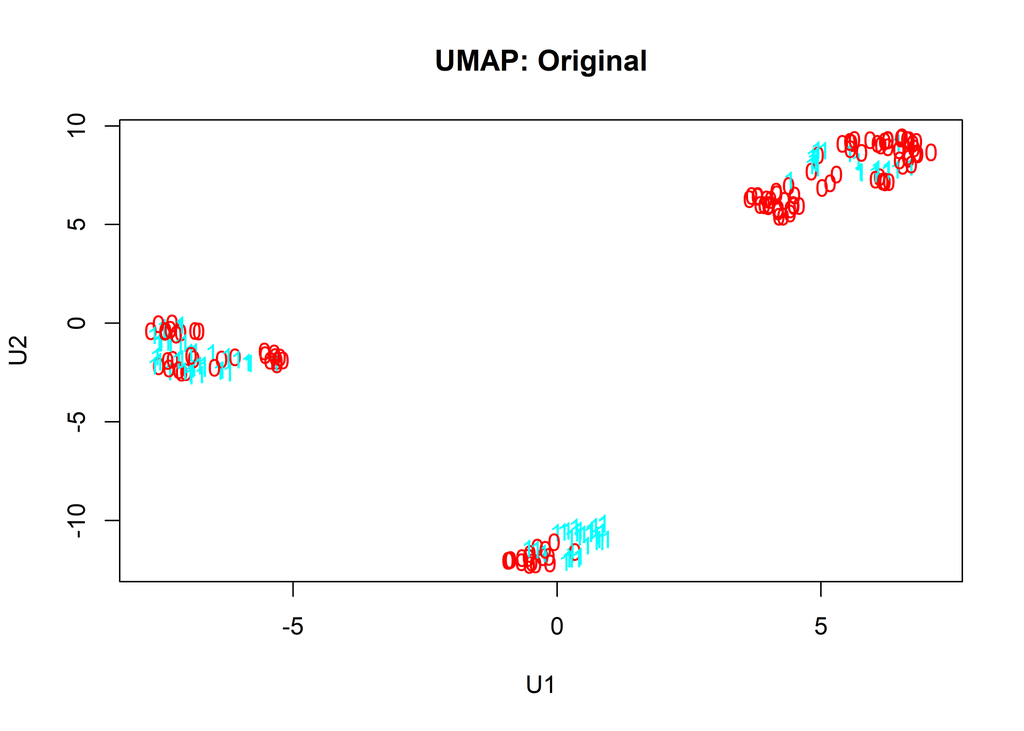

```r
classes <- unique(dataframe[,outcome])
raincolors <- rainbow(length(classes))
names(raincolors) <- classes
datasetframe.umap = umap(scale(dataframe[,varlist]),n_components=2)
plot(datasetframe.umap$layout,xlab="U1",ylab="U2",main="UMAP: Original",t='n')
text(datasetframe.umap$layout,labels=dataframe[,outcome],col=raincolors[dataframe[,outcome]+1])
```

### 1.8.2 The decorralted UMAP

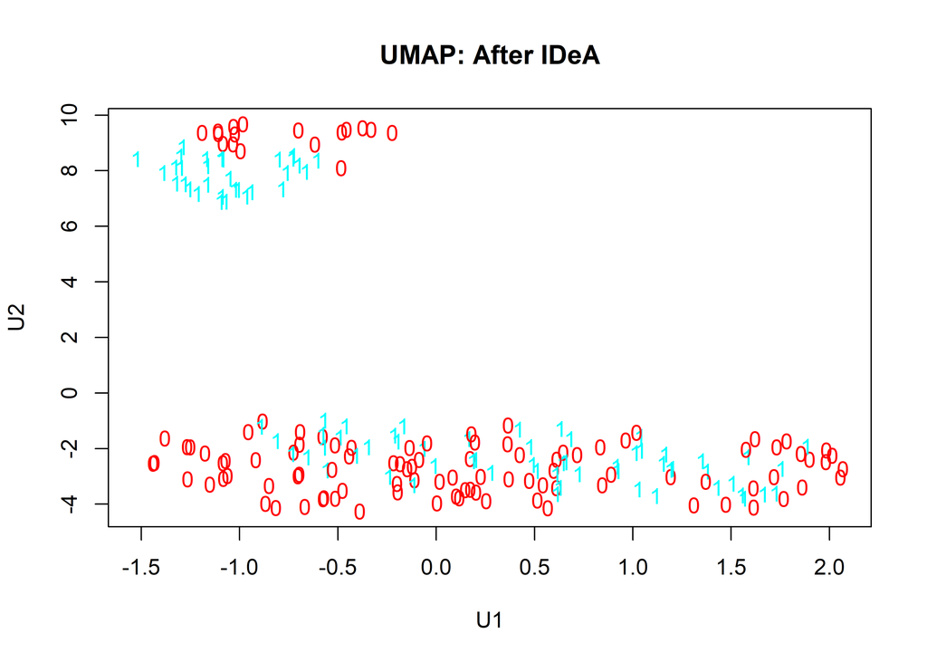

```r
datasetframe.umap = umap(scale(DEdataframe[,varlistc]),n_components=2)
plot(datasetframe.umap$layout,xlab="U1",ylab="U2",main="UMAP: After IDeA",t='n')
text(datasetframe.umap$layout,labels=DEdataframe[,outcome],col=raincolors[DEdataframe[,outcome]+1])
```

## 1.9 Univariate Analysis

### 1.9.1 Univariate

```r
univarRAW <- uniRankVar(varlist,
               paste(outcome,"~1"),
               outcome,
               dataframe,
               rankingTest="AUC")
```

100 : V100 200 : V201 300 : V302 400 : V402 500 : V504  
600 : V606 700 : V707 800 : V807 900 : V907 1000 : V1008  
1100 : V1108 1200 : V1209 1300 : V1309 1400 : V1409 1500 : V1509  
1600 : V1610 1700 : V1710 1800 : V1810 1900 : V1911 2000 : V2012  
2100 : V2113 2200 : V2213 2300 : V2313 2400 : V2417 2500 : V2518  
2600 : V2620 2700 : V2722 2800 : V2822 2900 : V2922 3000 : V3023  
3100 : V3123 3200 : V3223 3300 : V3326 3400 : V3428 3500 : V3528  
3600 : V3629 3700 : V3734 3800 : V3835 3900 : V3935 4000 : V4038  
4100 : V4140 4200 : V4243 4300 : V4344 4400 : V4445 4500 : V4547  
4600 : V4649 4700 : V4751 4800 : V4853 4900 : V4954 5000 : V5055  
5100 : V5156 5200 : V5256 5300 : V5360 5400 : V5462 5500 : V5564  
5600 : V5666 5700 : V5768 5800 : V5868 5900 : V5970 6000 : V6070  
6100 : V6171 6200 : V6271 6300 : V6372 6400 : V6473 6500 : V6573  
6600 : V6675 6700 : V6777 6800 : V6881 6900 : V6983 7000 : V7088  
7100 : V7190 7200 : V7291 7300 : V7393 7400 : V7496 7500 : V7597  
7600 : V7701 7700 : V7803 7800 : V7904 7900 : V8007 8000 : V8108  
8100 : V8209 8200 : V8310 8300 : V8414 8400 : V8516 8500 : V8620  
8600 : V8721 8700 : V8822 8800 : V8925 8900 : V9026 9000 : V9128  
9100 : V9232 9200 : V9332 9300 : V9433 9400 : V9533 9500 : V9638  
9600 : V9739 9700 : V9841 9800 : V9944

```r
univarDe <- uniRankVar(varlistc,
               paste(outcome,"~1"),
               outcome,
               DEdataframe,
               rankingTest="AUC",
               )
```

100 : V100 200 : La_V201 300 : V302 400 : La_V402 500 : V504  
600 : V606 700 : V707 800 : V807 900 : La_V907 1000 : La_V1008  
1100 : La_V1108 1200 : V1209 1300 : La_V1309 1400 : La_V1409 1500 : La_V1509  
1600 : La_V1610 1700 : La_V1710 1800 : La_V1810 1900 : La_V1911 2000 : La_V2012  
2100 : La_V2113 2200 : La_V2213 2300 : V2313 2400 : La_V2417 2500 : La_V2518  
2600 : V2620 2700 : La_V2722 2800 : V2822 2900 : V2922 3000 : La_V3023  
3100 : La_V3123 3200 : La_V3223 3300 : V3326 3400 : V3428 3500 : La_V3528  
3600 : La_V3629 3700 : La_V3734 3800 : La_V3835 3900 : V3935 4000 : La_V4038  
4100 : La_V4140 4200 : La_V4243 4300 : V4344 4400 : V4445 4500 : La_V4547  
4600 : La_V4649 4700 : La_V4751 4800 : V4853 4900 : La_V4954 5000 : La_V5055  
5100 : V5156 5200 : La_V5256 5300 : V5360 5400 : La_V5462 5500 : La_V5564  
5600 : La_V5666 5700 : La_V5768 5800 : La_V5868 5900 : La_V5970 6000 : La_V6070  
6100 : La_V6171 6200 : La_V6271 6300 : V6372 6400 : La_V6473 6500 : V6573  
6600 : La_V6675 6700 : La_V6777 6800 : V6881 6900 : La_V6983 7000 : La_V7088  
7100 : La_V7190 7200 : V7291 7300 : La_V7393 7400 : La_V7496 7500 : La_V7597  
7600 : La_V7701 7700 : La_V7803 7800 : La_V7904 7900 : V8007 8000 : La_V8108  
8100 : La_V8209 8200 : La_V8310 8300 : La_V8414 8400 : La_V8516 8500 : V8620  
8600 : La_V8721 8700 : La_V8822 8800 : La_V8925 8900 : V9026 9000 : V9128  
9100 : La_V9232 9200 : La_V9332 9300 : La_V9433 9400 : V9533 9500 : La_V9638  
9600 : La_V9739 9700 : La_V9841 9800 : V9944

### 1.9.2 Final Table

```r
univariate_columns <- c("caseMean","caseStd","controlMean","controlStd","controlKSP","ROCAUC")

##topfive
topvar <- c(1:length(varlist)) <= TopVariables
pander::pander(univarRAW$orderframe[topvar,univariate_columns])
```

|  | caseMean | caseStd | controlMean | controlStd | controlKSP | ROCAUC |
| --- | --- | --- | --- | --- | --- | --- |
| **V5005** | 0.2405 | 0.812 | -0.601 | 0.905 | 0.1698 | 0.772 |
| **V4960** | -0.1925 | 0.535 | 0.588 | 0.959 | 0.3477 | 0.751 |
| **V2309** | -0.1950 | 0.546 | 0.593 | 0.968 | 0.3450 | 0.751 |
| **V8368** | -0.2038 | 0.556 | 0.602 | 0.984 | 0.3869 | 0.751 |
| **V312** | -0.2062 | 0.539 | 0.582 | 0.964 | 0.3325 | 0.750 |
| **V3365** | -0.2092 | 0.548 | 0.590 | 0.975 | 0.3814 | 0.749 |
| **V9617** | -0.1981 | 0.548 | 0.585 | 0.968 | 0.2946 | 0.749 |
| **V414** | -0.1696 | 0.521 | 0.590 | 0.944 | 0.2850 | 0.749 |
| **V9092** | 0.0684 | 0.524 | 0.750 | 0.953 | 0.0021 | 0.748 |
| **V1936** | 0.3516 | 0.824 | -0.401 | 0.807 | 0.3255 | 0.748 |

```r
topLAvar <- univarDe$orderframe$Name[str_detect(univarDe$orderframe$Name,"La_")]
topLAvar <- unique(c(univarDe$orderframe$Name[topvar],topLAvar[1:as.integer(TopVariables/2)]))
finalTable <- univarDe$orderframe[topLAvar,univariate_columns]

theLaVar <- rownames(finalTable)[str_detect(rownames(finalTable),"La_")]

pander::pander(univarDe$orderframe[topLAvar,univariate_columns])
```

|  | caseMean | caseStd | controlMean | controlStd | controlKSP | ROCAUC |
| --- | --- | --- | --- | --- | --- | --- |
| **La_V9413** | -0.024457 | 0.0445 | 0.0374 | 0.0542 | 1.63e-05 | 0.816 |
| **La_V8743** | -0.012135 | 0.1157 | 0.0922 | 0.1152 | 1.90e-06 | 0.791 |
| **La_V983** | -0.000219 | 0.0106 | 0.0135 | 0.0156 | 1.43e-08 | 0.786 |
| **La_V571** | 0.002105 | 0.0501 | 0.0557 | 0.0532 | 1.25e-01 | 0.784 |
| **La_V9638** | 0.146639 | 0.1072 | 0.2688 | 0.1269 | 1.19e-01 | 0.782 |
| **La_V3620** | 0.192299 | 0.1899 | -0.0430 | 0.3459 | 8.17e-04 | 0.780 |
| **La_V7665** | 0.153841 | 0.2878 | -0.1305 | 0.3014 | 5.67e-01 | 0.773 |
| **La_V4039** | -0.041187 | 0.0610 | 0.0337 | 0.0906 | 1.49e-02 | 0.753 |
| **V5801** | 0.262367 | 0.6641 | -0.4783 | 0.8848 | 1.04e-01 | 0.744 |
| **La_V7728** | 0.015447 | 0.0412 | -0.0247 | 0.0497 | 2.78e-05 | 0.743 |

```r
dc <- getLatentCoefficients(DEdataframe)
fscores <- attr(DEdataframe,"fscore")

theSigDc <- dc[theLaVar]
names(theSigDc) <- NULL
theSigDc <- unique(names(unlist(theSigDc)))


theFormulas <- dc[rownames(finalTable)]
deFromula <- character(length(theFormulas))
names(deFromula) <- rownames(finalTable)

pander::pander(c(mean=mean(sapply(dc,length)),total=length(dc),fraction=length(dc)/(ncol(dataframe)-1)))
```

| mean | total | fraction |
| --- | --- | --- |
| 3.08 | 6567 | 0.666 |

```r
allSigvars <- names(dc)



dx <- names(deFromula)[1]
for (dx in names(deFromula))
{
  coef <- theFormulas[[dx]]
  cname <- names(theFormulas[[dx]])
  names(cname) <- cname
  for (cf in names(coef))
  {
    if (cf != dx)
    {
      if (coef[cf]>0)
      {
        deFromula[dx] <- paste(deFromula[dx],
                               sprintf("+ %5.3f*%s",coef[cf],cname[cf]))
      }
      else
      {
        deFromula[dx] <- paste(deFromula[dx],
                               sprintf("%5.3f*%s",coef[cf],cname[cf]))
      }
    }
  }
}

finalTable <- rbind(finalTable,univarRAW$orderframe[theSigDc[!(theSigDc %in% rownames(finalTable))],univariate_columns])


orgnamez <- rownames(finalTable)
orgnamez <- str_remove_all(orgnamez,"La_")
finalTable$RAWAUC <- univarRAW$orderframe[orgnamez,"ROCAUC"]
finalTable$DecorFormula <- deFromula[rownames(finalTable)]
finalTable$fscores <- fscores[rownames(finalTable)]

Final_Columns <- c("DecorFormula","caseMean","caseStd","controlMean","controlStd","controlKSP","ROCAUC","RAWAUC","fscores")

finalTable <- finalTable[order(-finalTable$ROCAUC),]
pander::pander(finalTable[,Final_Columns])
```

|  | DecorFormula | caseMean | caseStd | controlMean | controlStd | controlKSP | ROCAUC | RAWAUC | fscores |
| --- | --- | --- | --- | --- | --- | --- | --- | --- | --- |
| **La_V9413** | -0.996*V3945 + 1.000*V9413 | -0.024457 | 0.0445 | 0.0374 | 0.0542 | 1.63e-05 | 0.816 | 0.547 | 4 |
| **La_V8743** | -0.946*V6388 + 1.000*V8743 | -0.012135 | 0.1157 | 0.0922 | 0.1152 | 1.90e-06 | 0.791 | 0.533 | 1 |
| **La_V983** | + 0.218*V636 + 1.000*V983 -1.075*V2244 -0.150*V5078 | -0.000219 | 0.0106 | 0.0135 | 0.0156 | 1.43e-08 | 0.786 | 0.575 | -3 |
| **La_V571** | -1.102*V405 + 1.000*V571 -0.152*V7374 | 0.002105 | 0.0501 | 0.0557 | 0.0532 | 1.25e-01 | 0.784 | 0.598 | -2 |
| **La_V9638** | -0.434*V5805 + 1.000*V9638 -1.318*V9916 | 0.146639 | 0.1072 | 0.2688 | 0.1269 | 1.19e-01 | 0.782 | 0.583 | -2 |
| **La_V3620** | + 1.000*V3620 -0.950*V6217 | 0.192299 | 0.1899 | -0.0430 | 0.3459 | 8.17e-04 | 0.780 | 0.705 | 0 |
| **La_V7665** | -0.928*V5419 + 1.000*V7665 | 0.153841 | 0.2878 | -0.1305 | 0.3014 | 5.67e-01 | 0.773 | 0.514 | -1 |
| **La_V4039** | -0.967*V1333 -0.179*V2832 + 1.000*V4039 | -0.041187 | 0.0610 | 0.0337 | 0.0906 | 1.49e-02 | 0.753 | 0.631 | 1 |
| **V5801** |  | 0.262367 | 0.6641 | -0.4783 | 0.8848 | 1.04e-01 | 0.744 | 0.744 | 6 |
| **La_V7728** | + 1.000*V7728 + 2.451*V8111 -3.463*V8621 | 0.015447 | 0.0412 | -0.0247 | 0.0497 | 2.78e-05 | 0.743 | 0.590 | 1 |
| **V3620** | NA | 0.135192 | 0.6309 | -0.3169 | 0.5861 | 4.99e-04 | 0.705 | 0.705 | NA |
| **V1333** | NA | -0.008113 | 0.5437 | -0.3277 | 0.5852 | 9.08e-04 | 0.643 | 0.643 | NA |
| **V405** | NA | 0.174954 | 0.8223 | -0.2015 | 0.8162 | 9.96e-01 | 0.632 | 0.632 | 2 |
| **V4039** | NA | 0.003022 | 0.5580 | -0.2417 | 0.5915 | 2.32e-04 | 0.631 | 0.631 | NA |
| **V5078** | NA | 0.191150 | 0.5740 | -0.0498 | 0.5678 | 1.01e-03 | 0.630 | 0.630 | NA |
| **V6217** | NA | -0.060134 | 0.5487 | -0.2884 | 0.6140 | 8.54e-05 | 0.617 | 0.617 | NA |
| **V571** | NA | 0.206491 | 0.8934 | -0.1387 | 0.9474 | 8.02e-01 | 0.598 | 0.598 | NA |
| **V7728** | NA | -0.008874 | 0.5862 | -0.2189 | 0.6359 | 3.93e-05 | 0.590 | 0.590 | NA |
| **V8111** | NA | 0.031693 | 0.6172 | -0.1333 | 0.7637 | 2.46e-04 | 0.589 | 0.589 | NA |
| **V5419** | NA | -0.186835 | 0.7245 | 0.1128 | 0.8537 | 2.66e-01 | 0.586 | 0.586 | NA |
| **V8621** | NA | 0.015410 | 0.5963 | -0.1504 | 0.7171 | 1.14e-04 | 0.584 | 0.584 | NA |
| **V9638** | NA | -0.059599 | 0.9678 | 0.2760 | 1.1533 | 2.47e-01 | 0.583 | 0.583 | NA |
| **V983** | NA | 0.188922 | 0.6093 | 0.0373 | 0.6204 | 1.81e-03 | 0.575 | 0.575 | NA |
| **V2244** | NA | 0.172784 | 0.6085 | 0.0188 | 0.6374 | 1.82e-03 | 0.571 | 0.571 | NA |
| **V3945** | NA | 0.217718 | 0.6146 | 0.0873 | 0.6153 | 2.59e-03 | 0.571 | 0.571 | NA |
| **V636** | NA | 0.115673 | 0.6080 | -0.0509 | 0.6899 | 1.72e-03 | 0.568 | 0.568 | NA |
| **V6388** | NA | 0.375704 | 0.9089 | 0.1400 | 0.7525 | 4.63e-03 | 0.567 | 0.567 | NA |
| **V2832** | NA | 0.291414 | 0.6899 | 0.2322 | 0.7052 | 4.04e-05 | 0.564 | 0.564 | 14 |
| **V9916** | NA | -0.120196 | 0.7472 | 0.0408 | 0.8195 | 6.84e-01 | 0.552 | 0.552 | NA |
| **V9413** | NA | 0.192361 | 0.6183 | 0.1243 | 0.6173 | 3.58e-03 | 0.547 | 0.547 | NA |
| **V8743** | NA | 0.343214 | 0.8462 | 0.2246 | 0.7543 | 2.16e-03 | 0.533 | 0.533 | NA |
| **V7665** | NA | -0.019586 | 0.7204 | -0.0258 | 0.8953 | 5.52e-01 | 0.514 | 0.514 | NA |
| **V7374** | NA | 0.076352 | 0.7788 | 0.1826 | 1.1383 | 5.27e-01 | 0.510 | 0.510 | NA |
| **V5805** | NA | -0.110244 | 0.6857 | -0.1073 | 0.5955 | 6.82e-04 | 0.488 | 0.488 | NA |